# PART II:

### Data Visualization on Honey Production dataset using seaborn and matplotlib libraries.

## Domain: Food and agriculture

### Context:

In 2006, a global concern was raised over the rapid decline in the honeybee population, an integral component to American honey agriculture. Large numbers of hives were lost to “Colony-Collapse-Disorder”, a phenomenon of disappearing “worker-bees” causing the remaining “hive-colony” to collapse. Speculation around the cause of this disorder points to hive-diseases and pesticides harming the pollinators, though no overall consensus has been reached. Twelve years later, some industries are observing recovery but the American honey industry is still largely struggling. The U.S. used to locally produce over half the honey it consumes per year. Now, honey mostly comes from overseas, with 350 of the 400 million pounds of honey consumed every year originating from imports. This dataset provides insight into honey production supply and demand in America by state from 1998 to 2012.

### Objective:

The Goal is to use Python visualization libraries such as seaborn and matplotlib to investigate the data and get some useful conclusions.

### 1. Import required libraries and read the dataset.

```python
# importing required libraries and reading the dataset
import pandas as pd
import numpy as np
import matplotlib .pyplot as plt
import seaborn as sns

data_set=pd.read_csv("honeyproduction.csv")
```

```python
data_set
```

|  | state | numcol | yieldpercol | totalprod | stocks | priceperlb | prodvalue | year |
| --- | --- | --- | --- | --- | --- | --- | --- | --- |
| 0 | AL | 16000.0 | 71 | 1136000.0 | 159000.0 | 0.72 | 818000.0 | 1998 |
| 1 | AZ | 55000.0 | 60 | 3300000.0 | 1485000.0 | 0.64 | 2112000.0 | 1998 |
| 2 | AR | 53000.0 | 65 | 3445000.0 | 1688000.0 | 0.59 | 2033000.0 | 1998 |
| 3 | CA | 450000.0 | 83 | 37350000.0 | 12326000.0 | 0.62 | 23157000.0 | 1998 |
| 4 | CO | 27000.0 | 72 | 1944000.0 | 1594000.0 | 0.70 | 1361000.0 | 1998 |
| ... | ... | ... | ... | ... | ... | ... | ... | ... |
| 621 | VA | 4000.0 | 41 | 164000.0 | 23000.0 | 3.77 | 618000.0 | 2012 |
| 622 | WA | 62000.0 | 41 | 2542000.0 | 1017000.0 | 2.38 | 6050000.0 | 2012 |
| 623 | WV | 6000.0 | 48 | 288000.0 | 95000.0 | 2.91 | 838000.0 | 2012 |
| 624 | WI | 60000.0 | 69 | 4140000.0 | 1863000.0 | 2.05 | 8487000.0 | 2012 |
| 625 | WY | 50000.0 | 51 | 2550000.0 | 459000.0 | 1.87 | 4769000.0 | 2012 |

626 rows × 8 columns

### 2. Check the first few samples, shape, info of the data and try to familiarize yourself with different features.

```python
#Top 5 Rows of the dataset.
data_set.head()
```

|  | state | numcol | yieldpercol | totalprod | stocks | priceperlb | prodvalue | year |
| --- | --- | --- | --- | --- | --- | --- | --- | --- |
| 0 | AL | 16000.0 | 71 | 1136000.0 | 159000.0 | 0.72 | 818000.0 | 1998 |
| 1 | AZ | 55000.0 | 60 | 3300000.0 | 1485000.0 | 0.64 | 2112000.0 | 1998 |
| 2 | AR | 53000.0 | 65 | 3445000.0 | 1688000.0 | 0.59 | 2033000.0 | 1998 |
| 3 | CA | 450000.0 | 83 | 37350000.0 | 12326000.0 | 0.62 | 23157000.0 | 1998 |
| 4 | CO | 27000.0 | 72 | 1944000.0 | 1594000.0 | 0.70 | 1361000.0 | 1998 |

```python
# Bottom 5 Rows of the dataset
data_set.tail()
```

|  | state | numcol | yieldpercol | totalprod | stocks | priceperlb | prodvalue | year |
| --- | --- | --- | --- | --- | --- | --- | --- | --- |
| 621 | VA | 4000.0 | 41 | 164000.0 | 23000.0 | 3.77 | 618000.0 | 2012 |
| 622 | WA | 62000.0 | 41 | 2542000.0 | 1017000.0 | 2.38 | 6050000.0 | 2012 |
| 623 | WV | 6000.0 | 48 | 288000.0 | 95000.0 | 2.91 | 838000.0 | 2012 |
| 624 | WI | 60000.0 | 69 | 4140000.0 | 1863000.0 | 2.05 | 8487000.0 | 2012 |
| 625 | WY | 50000.0 | 51 | 2550000.0 | 459000.0 | 1.87 | 4769000.0 | 2012 |

```python
data_set.shape
```

```
(626, 8)
```

```python
data_set.info()
```

```
<class 'pandas.core.frame.DataFrame'>
RangeIndex: 626 entries, 0 to 625
Data columns (total 8 columns):
 #   Column       Non-Null Count  Dtype
---  ------       --------------  -----
 0   state        626 non-null    object
 1   numcol       626 non-null    float64
 2   yieldpercol  626 non-null    int64
 3   totalprod    626 non-null    float64
 4   stocks       626 non-null    float64
 5   priceperlb   626 non-null    float64
 6   prodvalue    626 non-null    float64
 7   year         626 non-null    int64
dtypes: float64(5), int64(2), object(1)
memory usage: 39.3+ KB
```

```python
data_set.describe()
```

|  | numcol | yieldpercol | totalprod | stocks | priceperlb | prodvalue | year |
| --- | --- | --- | --- | --- | --- | --- | --- |
| count | 626.000000 | 626.000000 | 6.260000e+02 | 6.260000e+02 | 626.000000 | 6.260000e+02 | 626.000000 |
| mean | 60284.345048 | 62.009585 | 4.169086e+06 | 1.318859e+06 | 1.409569 | 4.715741e+06 | 2004.864217 |
| std | 91077.087231 | 19.458754 | 6.883847e+06 | 2.272964e+06 | 0.638599 | 7.976110e+06 | 4.317306 |
| min | 2000.000000 | 19.000000 | 8.400000e+04 | 8.000000e+03 | 0.490000 | 1.620000e+05 | 1998.000000 |
| 25% | 9000.000000 | 48.000000 | 4.750000e+05 | 1.430000e+05 | 0.932500 | 7.592500e+05 | 2001.000000 |
| 50% | 26000.000000 | 60.000000 | 1.533000e+06 | 4.395000e+05 | 1.360000 | 1.841500e+06 | 2005.000000 |
| 75% | 63750.000000 | 74.000000 | 4.175250e+06 | 1.489500e+06 | 1.680000 | 4.703250e+06 | 2009.000000 |
| max | 510000.000000 | 136.000000 | 4.641000e+07 | 1.380000e+07 | 4.150000 | 6.961500e+07 | 2012.000000 |

### 3. Display the percentage distribution of the data in each year using the pie chart.

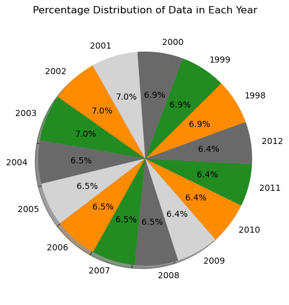

```python
# percentage distribution of the data in each year
plt.figure(figsize=(5,6))
year_distribution = data_set.groupby('year').size()/len(data_set)*100
my_colors = ["darkorange","forestgreen","dimgrey","lightgray"]
plt.pie(year_distribution, labels=year_distribution.index, autopct='%1.1f%%', startangle=20, shadow = True, colors=my_colors)
plt.title('Percentage Distribution of Data in Each Year')
plt.axis('equal')
plt.show()
plt.tight_layout();
```

### 4. Plot and Understand the distribution of the variable "price per lb" using displot, and write your findings.

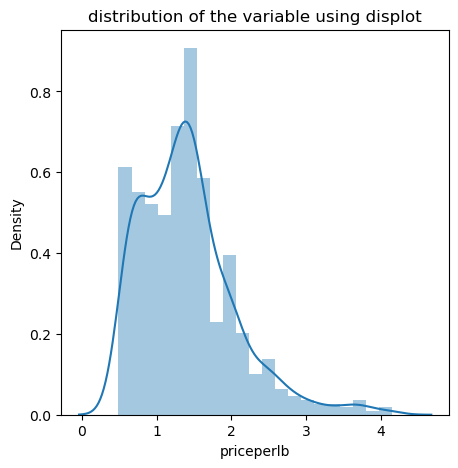

```python
# plotting displot of variable
plt.figure(figsize=(5,5))
sns.distplot(data_set['priceperlb'])
plt.title("distribution of the variable using displot")
plt.show()
```

### Inference:

The description suggests that as the price per pound increases,the sales decrease. The price per lb indicates the average price of honey per pound based on sales. Honey costs more per pound, it seems that not as many people are purchasing it.

### 5. Plot and understand the relationship between the variables 'numcol' and 'prodval' through scatterplot, and write your findings.

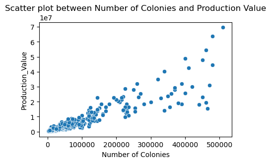

```python
plt.figure(figsize=(5,3))
sns.scatterplot(x=data_set["numcol"], y=data_set["prodvalue"], data=data_set)
plt.xlabel('Number of Colonies')
plt.ylabel('Production_Value')
plt.title('Scatter plot between Number of Colonies and Production Value')
plt.show()
```

### Conclusion:

The above scatter plot suggests that there is a positive correlation between the number of colonies and the production value of honey. This means,as the number of colonies increases, the production value of honey also increases. Increasing the number of colonies will help us produce more honey.

### 6. Plot and understand the relationship between categorical variable 'year' and a numerical variable 'prodvalue' through boxplot, and write your findings.

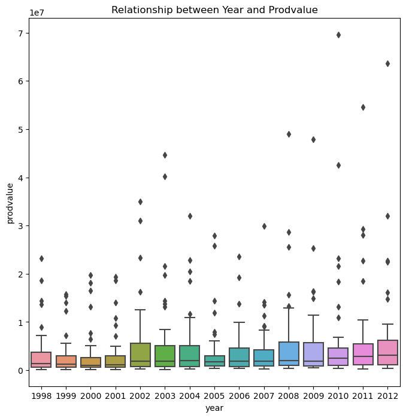

```python
plt.figure(figsize=(8,8))
sns.boxplot(x='year', y='prodvalue', data=data_set)
plt.title('Relationship between Year and Prodvalue')
plt.show()
```

### Inference:

From the above Box-plot,It observed that as the year passes the sales increases. The median'prodvalue' also increases over the years. The boxplot suggests a positive relationship between the year and prodvalue, indicating that,on average, honey production value has been increasing over the years, it support the idea of growth in sales.

### 7. Visualize and understand the relationship between the multiple pairs of variables throughout different years using pairplot and add your inferences. (use columns 'numcol', 'yield percol', 'total prod', 'prodvalue','year')

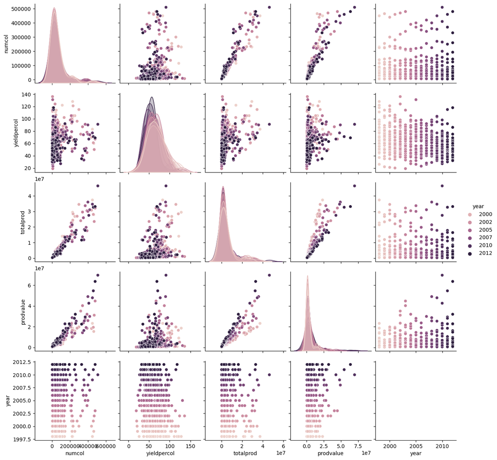

```python
sns.pairplot(data_set, hue='year',vars=['numcol', 'yieldpercol', 'totalprod', 'prodvalue', 'year'])
plt.show()
```

### Conclusion

From the above pair plot,It observed that,

- numcol and totalprod: numcol and totalprod variables are positively correlated, indicating that as the number of colonies increases,the total honey production also tends to increase.
- yieldpercol and prodvalue: A positive correlation between yieldpercol and prodvalue variables suggests that higher yields per colony are associated with greater production values.
- totalprod and prodvalue: These variables are also positively correlated, indicating that higher total production tends to result in higher production values.
- The Features such as numcol,totalprod and prodvalue are positively skewed in nature, whereas yieldpercol is normally distributed.

### 8. Display the correlation values using a plot and add your inferences. (use columns 'numcol', 'yield percol','total prod', 'stocks', 'price per lb', 'prodvalue')

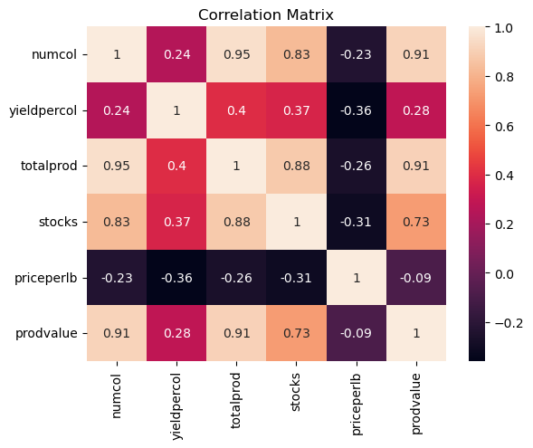

```python
da_ta= data_set[['numcol', 'yieldpercol', 'totalprod', 'stocks', 'priceperlb', 'prodvalue']]
corr_matrix = da_ta.corr()
sns.heatmap(corr_matrix, annot=True)
plt.title("Correlation Matrix")
plt.show()
```

### Inference:

The Features such as numcol,totalprod and prodvalue are positively Skewed distributions.Implying that their data is concentrated on the lower end of the scale with a long tail extending to the right. yieldpercol is normally distributed. numcol and totalprod variables appear to have a positive correlation, meaning that as the number of colonies increases,total production also tends to increase. yieldpercol and prodvalue have a positive cor-relation,As yield per colony increase, production value tends to increase. totalprod and prodvalue variables seem to be positively correlated,indicating that higher total production is associated with greater production value.